# Розрахункова Графічна Робота: Статистичний аналіз розмірів файлів

Варакута Олександр КІ-24-1

03.06.2025

# 1 Вступ

Ця робота має на меті провести **статистичний аналіз розмірів файлів** у вибраній директорії. Ми отримаємо дані про розміри файлів, побудуємо графіки та обчислимо основні статистичні характеристики.

## 1.1 ️ Імпорт необхідних бібліотек

```r
library(ggplot2)
library(dplyr)
library(tidyr)
library(scales)
library(forcats)
library(DT)
```

## 1.2 ️ Параметри аналізу

```r
# Директорія для аналізу
directory <- "C:/Windows"

# Кількість файлів для аналізу
n_files <- 100
```

## 1.3 ️ Отримання та обробка даних

```r
# Перевірка існування директорії
if (!dir.exists(directory)) {
  stop("Вказана директорія не існує!")
}

# Отримуємо список файлів
all_files <- list.files(directory, full.names = TRUE, recursive = TRUE)

# Інформація про файли
file_info <- file.info(all_files)
file_info <- file_info[!file_info$isdir, ]

# Обмежуємо кількість файлів
files <- head(rownames(file_info), n_files)
file_sizes <- file_info$size[match(files, rownames(file_info))]
file_sizes <- na.omit(file_sizes)

# Створюємо датафрейм
file_data <- data.frame(
  File = basename(files),
  Path = files,
  Size_Bytes = file_sizes,
  Size_KB = file_sizes / 1024,
  Size_MB = file_sizes / (1024^2)
)
```

## 1.4 ️ Перевірка даних

```r
cat("Аналізуємо", nrow(file_data), "файлів з директорії", directory, "\n")
```

```
## Аналізуємо 100 файлів з директорії C:/Windows
```

```r
head(file_data)
```

|  | File | Path | Size_Bytes | Size_KB | Size_MB |
| --- | --- | --- | --- | --- | --- |
| 1 | acpimof.dll | C:/Windows/acpimof.dll | 13576 | 1.325781e+01 | 1.294708e-02 |
| 2 | FXSEXT.ecf | C:/Windows/addins/FXSEXT.ecf | 802 | 7.832031e-01 | 7.648468e-04 |
| 3 | PcaAppLaunchDic.txt | C:/Windows/appcompat/pca/PcaAppLaunchDic.txt | 72284 | 7.058984e+01 | 6.893539e-02 |
| 4 | PcaGeneralDb0.txt | C:/Windows/appcompat/pca/PcaGeneralDb0.txt | 1731436 | 1.690855e+03 | 1.651226e+00 |
| 5 | PcaGeneralDb1.txt | C:/Windows/appcompat/pca/PcaGeneralDb1.txt | 0 | 0.000000e+00 | 0.000000e+00 |
| 6 | PcaWallpaperApp.txt | C:/Windows/appcompat/pca/PcaWallpaperApp.txt | 94 | 9.179688e-02 | 8.964539e-05 |

## 1.5 ️ Візуалізація розподілу розмірів

### 1.5.1 Гістограма

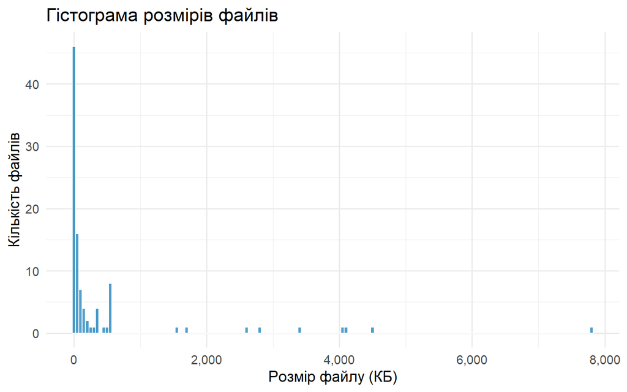

```r
ggplot(file_data, aes(x = Size_KB)) +
  geom_histogram(binwidth = 50, fill = "#0072B2", color = "white", alpha = 0.7) +
  labs(
    title = "Гістограма розмірів файлів",
    x = "Розмір файлу (КБ)",
    y = "Кількість файлів"
  ) +
  theme_minimal(base_size = 14) +
  scale_x_continuous(labels = scales::comma)
```

### 1.5.2 Boxplot

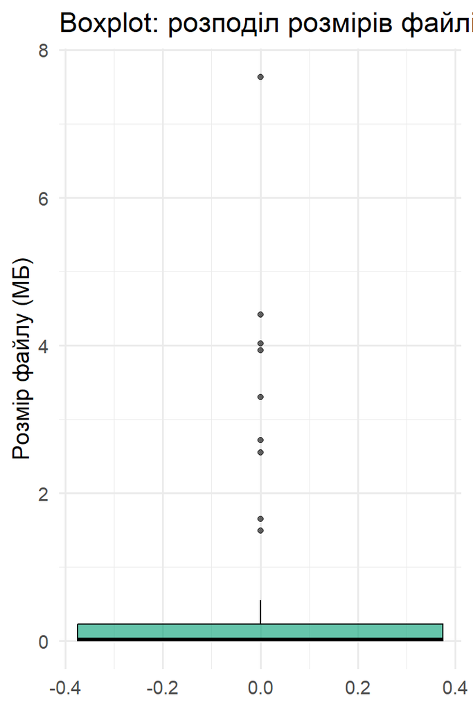

```r
ggplot(file_data, aes(y = Size_MB)) +
  geom_boxplot(fill = "#009E73", color = "black", alpha = 0.6) +
  labs(
    title = "Boxplot: розподіл розмірів файлів (МБ)",
    y = "Розмір файлу (МБ)"
  ) +
  theme_minimal(base_size = 14)
```

### 1.5.3 Violin plot

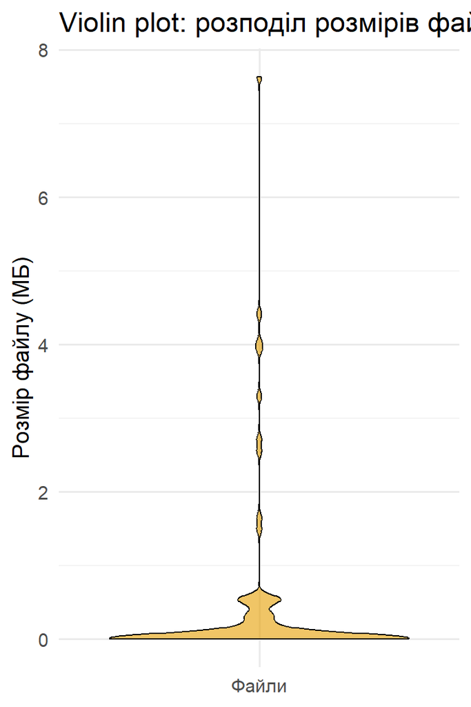

```r
ggplot(file_data, aes(y = Size_MB, x = "Файли")) +
  geom_violin(fill = "#E69F00", color = "black", alpha = 0.6) +
  labs(
    title = "Violin plot: розподіл розмірів файлів (МБ)",
    y = "Розмір файлу (МБ)",
    x = NULL
  ) +
  theme_minimal(base_size = 14)
```

## 1.6 ️ Статистичні характеристики

```r
mean_size <- mean(file_data$Size_Bytes)
median_size <- median(file_data$Size_Bytes)
var_size <- var(file_data$Size_Bytes)
sd_size <- sd(file_data$Size_Bytes)

cat("Середній розмір файлу:", round(mean_size / 1024, 2), "КБ\n")
```

```
## Середній розмір файлу: 424.84 КБ
```

```r
cat("Медіана:", round(median_size / 1024, 2), "КБ\n")
```

```
## Медіана: 32.48 КБ
```

```r
cat("Дисперсія:", round(var_size / (1024^2), 2), "МБ²\n")
```

[output not shown]

```r
cat("Стандартне відхилення:", round(sd_size / 1024, 2), "КБ\n")
```

```
## Стандартне відхилення: 1154.18 КБ
```

## 1.7 ️ Частка великих файлів (понад 1 МБ)

```r
threshold <- 1 * 1024^2
over_threshold <- mean(file_data$Size_Bytes > threshold)
cat("Частка файлів понад 1 МБ:", round(over_threshold * 100, 2), "%\n")
```

```
## Частка файлів понад 1 МБ: 9 %
```

## 1.8 ️ Таблиці для перегляду

### 1.8.1 Таблиця всіх файлів

```r
datatable(
  file_data %>%
    select(File, Size_Bytes, Size_KB, Size_MB),
  options = list(pageLength = 10, scrollX = TRUE),
  colnames = c("Файл", "Розмір (Б)", "Розмір (КБ)", "Розмір (МБ)")
)
```

|  | Файл | Розмір (Б) | Розмір (КБ) | Розмір (МБ) |
| --- | --- | --- | --- | --- |
| 1 | acpimof.dll | 13576 | 13.2578125 | 0.01294708251953125 |
| 2 | FXSEXT.ecf | 802 | 0.783203125 | 0.0007648468017578125 |
| 3 | PcaAppLaunchDic.txt | 72284 | 70.58984375 | 0.06893539428710938 |
| 4 | PcaGeneralDb0.txt | 1731436 | 1690.85546875 | 1.651226043701172 |
| 5 | PcaGeneralDb1.txt | 0 | 0 | 0 |
| 6 | PcaWallpaperApp.txt | 94 | 0.091796875 | 8.96453857421875e-05 |
| 7 | Appraiser_GE24H2.JSON | 1413 | 1.3798828125 | 0.001347541809082031 |
| 8 | Appraiser_NI22H2.JSON | 1413 | 1.3798828125 | 0.001347541809082031 |
| 9 | Appraiser_NI23H2.JSON | 1413 | 1.3798828125 | 0.001347541809082031 |
| 10 | classicon_{4d36e97b-e325-11ce-bfc1-08002be10318}.png | 1241 | 1.2119140625 | 0.001183509826660156 |

[output cut: 90 more lines]

### 1.8.2 10 найбільших файлів

```r
file_data %>%
  arrange(desc(Size_Bytes)) %>%
  slice_head(n = 10) %>%
  mutate(Size_MB = round(Size_MB, 2)) %>%
  select(File, Size_MB)
```

| File | Size_MB |
| --- | --- |
| Microsoft.mshtml.dll | 7.64 |
| mscorlib.dll | 4.41 |
| PresentationCore.dll | 4.03 |
| sysmain.sdb | 3.94 |
| msimain.sdb | 3.30 |
| Microsoft.DirectX.Direct3DX.dll | 2.71 |
| Microsoft.DirectX.Direct3DX.dll | 2.55 |
| PcaGeneralDb0.txt | 1.65 |
| DirectXApps.sdb | 1.49 |
| Microsoft.DirectX.Direct3DX.dll | 0.55 |

## 1.9 ️ Висновки

- Більшість файлів мають невеликий розмір – це типовий результат для системної директорії, де зберігається багато службових файлів.
- Медіанний розмір значно менший за середній, що вказує на правосторонню асиметрію розподілу (наявність кількох великих файлів, які суттєво впливають на середнє).
- Розподіл розмірів файлів досить широкий – ми бачимо значне стандартне відхилення, а також значну варіацію розмірів.
- Boxplot та Violin plot показують наявність викидів (великих файлів), що є характерною рисою даних про файлову систему.
- Частка файлів понад 1 МБ залишається низькою, хоча такі файли і мають помітний вплив на загальну статистику.
- Використання n_files <- 100 дозволило зменшити навантаження при аналізі та пришвидшило побудову графіків, однак варто пам’ятати, що результати репрезентують тільки частину всієї директорії.
- Ці результати можуть бути корисні для оптимізації файлової структури, виявлення потенційно великих файлів для видалення або резервного копіювання.

## 1.10 ️ Джерела

- [R language](https://www.r-project.org/)
- [ggplot2](https://ggplot2.tidyverse.org/)
- [dplyr](https://dplyr.tidyverse.org/)
- [DT](https://rstudio.github.io/DT/)
- [scales](https://scales.r-lib.org/)
- ChatGPT